# Box-Jenkins Forecasting: SARIMA Modeling of Pharmaceutical Sales

Evaluating Seasonal Demand and Model Ensembles for Antihistamine Sales (R06)

# 1 Introduction & Problem Framing

This project applies the Box-Jenkins methodology to analyze and forecast the sales volume of pharmaceutical products, specifically focusing on the R06 category (Antihistamines for systemic use).  
The dataset consists of Pharmacy Point-of-Sale transactions, which have been aggregated to a monthly frequency.

Because antihistamine demand is heavily driven by real-world biological cycles, this series is expected to exhibit strong, predictable seasonal fluctuations.

Accurate forecasting on this localized scale holds significant business value for individual pharmacies. It allows them to anticipate peak demand, optimize inventory procurement, and prevent stock-outs.

By validating a parsimonious ARIMA model, this analysis aims to determine whether short-term antihistamine demand can be reliably predicted using only its own historical autoregressive and seasonal memory.

# 2 Exploratory Data Analysis & Preprocessing

## 2.1 Visual Inspection and STL Decomposition

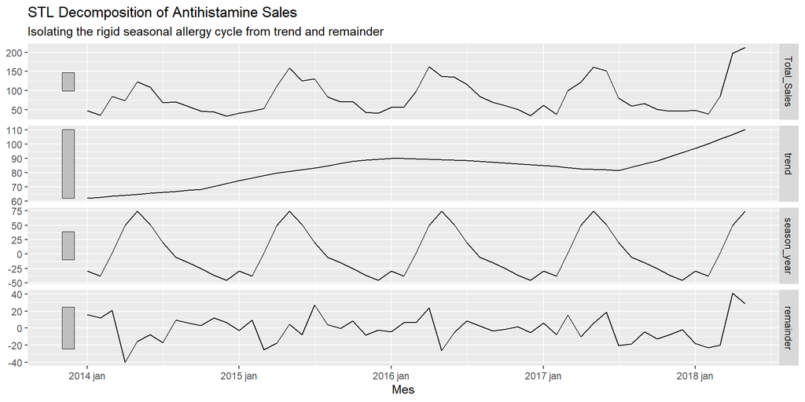

Visual inspection of the raw antihistamine sales reveals a clear 12-month seasonal pattern. Furthermore, the amplitude of the seasonal fluctuations is not constant; the variance appears to increase with the level of the series. Because the variance is non-constant, a variance stabilization transformation is formally required before proceeding to stationarity tests.

## 2.2 Variance Stabilization Evaluation

Variance Stabilization Diagnostic (Training Set)

| Method | Optimal_Lambda | Transformation |
| --- | --- | --- |
| Guerrero Optimization | -0.312 | Box-Cox Required |

During our initial visual inspection, the amplitude of the seasonal sales fluctuations appeared to increase alongside the overall level of the series, suggesting non-constant variance. To formally test this, we applied the Guerrero method to the training data. The calculation yielded an optimal Box-Cox parameter (λ) of -0.312, which is significantly distinct of 1.0.

This mathematical result confirms our visual hypothesis: the variance is non-constant. Therefore, the Box-Cox transformation is strictly required to stabilize the variance across the series, satisfying the prerequisite assumptions for formal Box-Jenkins estimation.

## 2.3 Stationarity Diagnostics and Differencing

ADF Unit Root Diagnostics (GTS Procedure). T-test for zero mean on differenced series: p = 0.4239

[output not shown]

# 3 Model Identification (ACF & PACF)

## 3.1 ACF and PACF Diagnostics

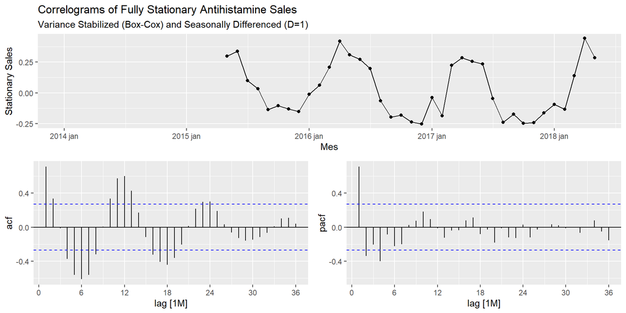

## 3.2 Model Estimation and Information Criteria

Auto ARIMA: ARIMA(1,0,1)(0,1,1)[12] — Coefficient Estimates

| .model | term | estimate | std.error | statistic | p.value |
| --- | --- | --- | --- | --- | --- |
| Auto_ARIMA | ar1 | 0.9786 | 0.1254 | 7.8024 | < 0.001 |
| Auto_ARIMA | ma1 | -0.7770 | 0.1342 | -5.7885 | < 0.001 |
| Auto_ARIMA | sma1 | -0.8552 | 0.6623 | -1.2913 | 0.2038 |

Information Criteria (AICc & BIC) for Candidate SARIMA Models

| .model | AICc | BIC |
| --- | --- | --- |
| sarima101011 | -105.34 | -99.60 |
| sarima000011 | -102.10 | -98.99 |
| sarima001011 | -100.94 | -96.45 |
| sarima200110 | -100.87 | -95.12 |
| sarima000111 | -99.89 | -95.40 |
| sarima000110 | -99.87 | -95.38 |
| sarima001111 | -98.57 | -92.83 |
| sarima100110 | -97.72 | -91.98 |
| sarima001110 | -97.60 | -91.86 |

SARIMA(0,0,0)(0,1,1)[12] — Coefficient Estimates

| term | estimate | std.error | statistic | p.value |
| --- | --- | --- | --- | --- |
| sma1 | -0.5934 | 0.2537 | -2.3389 | 0.0243 |

# 4 Residual Diagnostics

To validate the model for forecasting, we must ensure its residuals are consistent with white noise. We analyze the residual Autocorrelation Function (ACF) visually and formally test for remaining serial dependence using the Ljung-Box test.

```
##
##
## Table: Ljung-Box test (lag=24) with model-specific degrees of freedom
##
## |    Model     | DoF | Ljung-Box stat | p-value |
## |:------------:|:---:|:--------------:|:-------:|
## | sarima000110 |  2  |    53.7653     | 0.0002  |
## | sarima001110 |  3  |    48.9129     | 0.0005  |
## | sarima100110 |  3  |    46.2774     | 0.0012  |
## | sarima000011 |  1  |    47.2358     | 0.0021  |
## | sarima000111 |  2  |    45.4349     | 0.0023  |
## | sarima200110 |  3  |    34.9989     | 0.0282  |
## | sarima001011 |  2  |    36.0004     | 0.0304  |
## | sarima001111 |  3  |    34.6999     | 0.0305  |
## | sarima101011 |  3  |    23.9776     | 0.2941  |
```

# 5 IN-Sample Forecast Evaluation

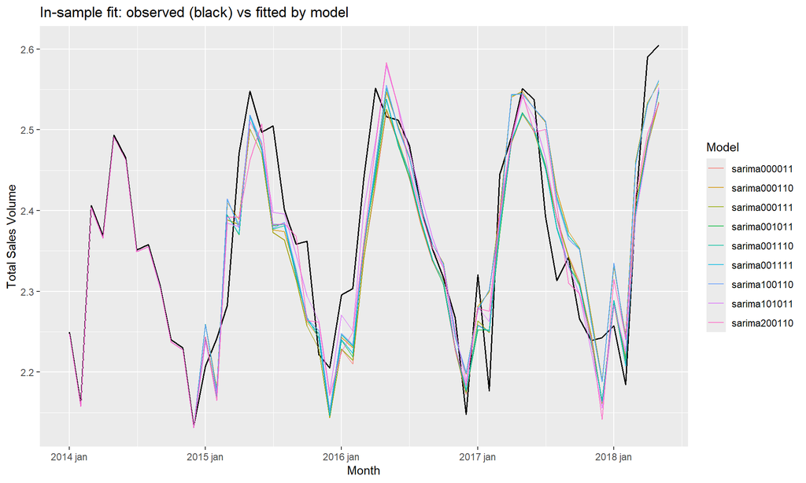

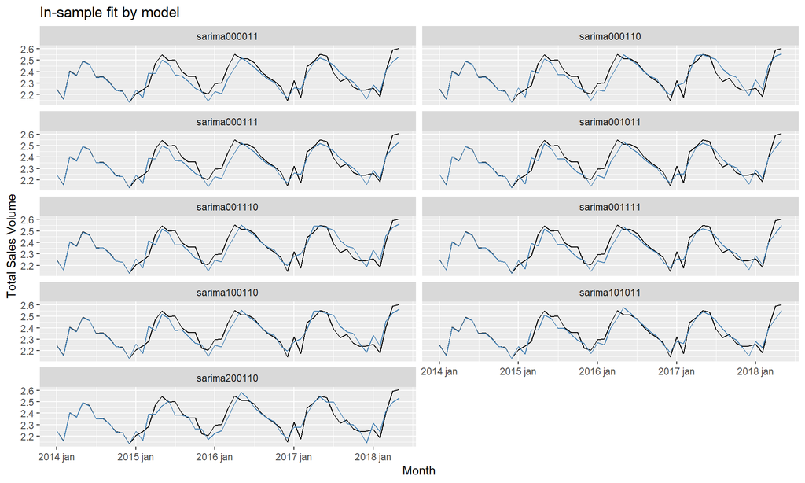

In-Sample Forecast Accuracy — All Candidate Models

| .model | RMSE | MAE | MAPE | MASE |
| --- | --- | --- | --- | --- |
| sarima101011 | 0.0457 | 0.0331 | 1.3978 | 0.5631 |
| sarima001111 | 0.0513 | 0.0379 | 1.5960 | 0.6454 |
| sarima001011 | 0.0525 | 0.0391 | 1.6465 | 0.6656 |
| sarima000111 | 0.0539 | 0.0395 | 1.6608 | 0.6726 |
| sarima200110 | 0.0545 | 0.0401 | 1.6970 | 0.6836 |
| sarima000011 | 0.0547 | 0.0404 | 1.6990 | 0.6879 |
| sarima100110 | 0.0564 | 0.0417 | 1.7741 | 0.7098 |
| sarima001110 | 0.0565 | 0.0419 | 1.7819 | 0.7130 |
| sarima000110 | 0.0567 | 0.0421 | 1.7900 | 0.7162 |

# 6 Out-of-Sample Forecast Evaluation

[figure not shown]

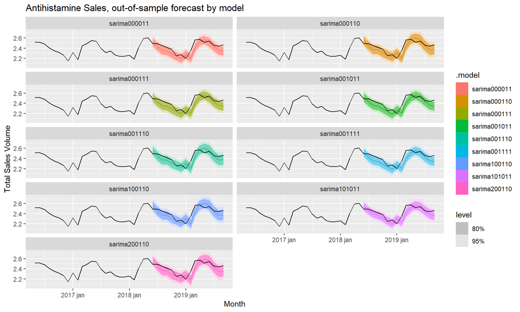

Out-of-Sample Forecast Accuracy (16-Month Holdout)

| .model | RMSE | MAE | MAPE | MASE |
| --- | --- | --- | --- | --- |
| sarima101011 | 0.0690 | 0.0583 | 2.4121 | 0.9931 |
| sarima000110 | 0.0758 | 0.0645 | 2.6734 | 1.0986 |
| sarima001110 | 0.0758 | 0.0646 | 2.6767 | 1.0998 |
| sarima100110 | 0.0758 | 0.0647 | 2.6798 | 1.1011 |
| sarima000011 | 0.0826 | 0.0716 | 2.9542 | 1.2198 |
| sarima001011 | 0.0827 | 0.0719 | 2.9647 | 1.2248 |
| sarima001111 | 0.0842 | 0.0735 | 3.0265 | 1.2516 |
| sarima000111 | 0.0843 | 0.0734 | 3.0242 | 1.2502 |
| sarima200110 | 0.0843 | 0.0714 | 2.9464 | 1.2152 |

In-sample vs out-of-sample accuracy

| Type | .model | RMSE | MAE | MAPE | MASE |
| --- | --- | --- | --- | --- | --- |
| **In-sample** |  |  |  |  |  |
| In-sample | sarima101011 | 0.0457 | 0.0331 | 1.3978 | 0.5631 |
| In-sample | sarima001111 | 0.0513 | 0.0379 | 1.5960 | 0.6454 |
| In-sample | sarima001011 | 0.0525 | 0.0391 | 1.6465 | 0.6656 |
| In-sample | sarima000111 | 0.0539 | 0.0395 | 1.6608 | 0.6726 |
| In-sample | sarima200110 | 0.0545 | 0.0401 | 1.6970 | 0.6836 |
| In-sample | sarima000011 | 0.0547 | 0.0404 | 1.6990 | 0.6879 |
| In-sample | sarima100110 | 0.0564 | 0.0417 | 1.7741 | 0.7098 |
| In-sample | sarima001110 | 0.0565 | 0.0419 | 1.7819 | 0.7130 |
| In-sample | sarima000110 | 0.0567 | 0.0421 | 1.7900 | 0.7162 |
| **Out-of-sample** |  |  |  |  |  |
| Out-of-sample | sarima101011 | 0.0690 | 0.0583 | 2.4121 | 0.9931 |
| Out-of-sample | sarima000110 | 0.0758 | 0.0645 | 2.6734 | 1.0986 |
| Out-of-sample | sarima001110 | 0.0758 | 0.0646 | 2.6767 | 1.0998 |
| Out-of-sample | sarima100110 | 0.0758 | 0.0647 | 2.6798 | 1.1011 |
| Out-of-sample | sarima000011 | 0.0826 | 0.0716 | 2.9542 | 1.2198 |
| Out-of-sample | sarima001011 | 0.0827 | 0.0719 | 2.9647 | 1.2248 |
| Out-of-sample | sarima001111 | 0.0842 | 0.0735 | 3.0265 | 1.2516 |
| Out-of-sample | sarima000111 | 0.0843 | 0.0734 | 3.0242 | 1.2502 |
| Out-of-sample | sarima200110 | 0.0843 | 0.0714 | 2.9464 | 1.2152 |

First, we evaluated the accuracy of the models within the first 53 months of training data. Next, we evaluated the accuracy of the results from the 16 months of test data.

## 6.1 Forcast Combination

| .model | RMSE | w |
| --- | --- | --- |
| sarima200110 | 0.0545 | 0.2331 |
| sarima101011 | 0.0457 | 0.2777 |
| sarima001011 | 0.0525 | 0.2418 |
| sarima001111 | 0.0513 | 0.2474 |

Individual Models vs RMSE-Weighted Combination

| .model | RMSE |
| --- | --- |
| sarima101011 | 0.0690 |
| sarima000110 | 0.0758 |
| sarima001110 | 0.0758 |
| sarima100110 | 0.0758 |
| combo_rmse | 0.0786 |
| sarima000011 | 0.0826 |
| sarima001011 | 0.0827 |
| sarima001111 | 0.0842 |
| sarima000111 | 0.0843 |
| sarima200110 | 0.0843 |

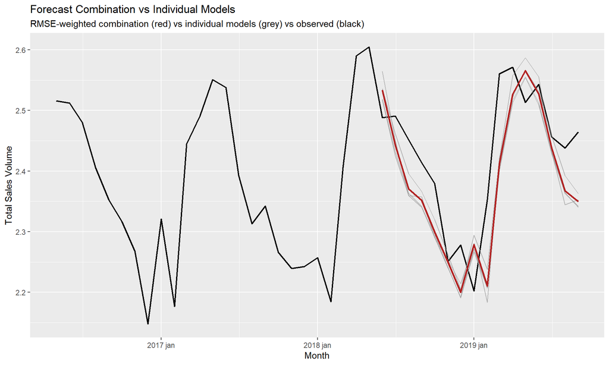

## 6.2 Out-of-Sample Forecast Evaluation

Out-of-Sample Forecast Accuracy (16-Month Holdout)

| .model | RMSE | MAE | MAPE | MASE |
| --- | --- | --- | --- | --- |
| ETS | 0.0678 | 0.0576 | 2.3812 | 0.9805 |
| sarima101011 | 0.0690 | 0.0583 | 2.4121 | 0.9931 |
| Seasonal_Naive | 0.0965 | 0.0826 | 3.3914 | 1.4059 |
| Historical_Mean | 0.1274 | 0.1136 | 4.6388 | 1.9345 |

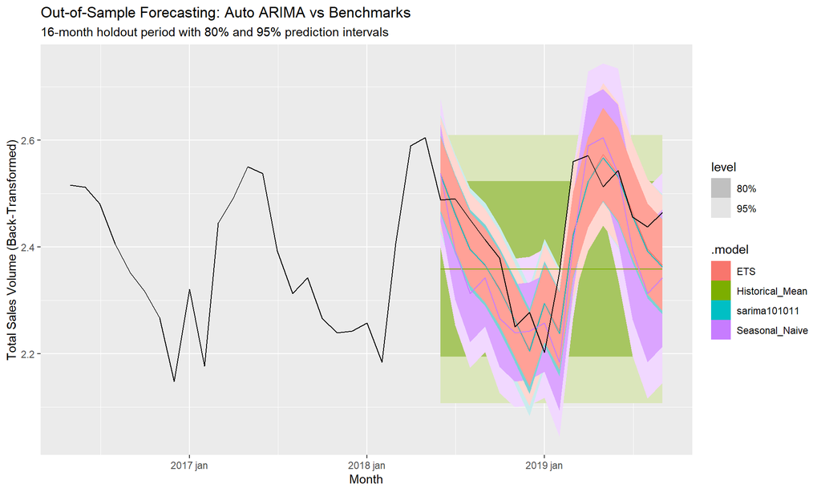

Auto ARIMA, ETS, Seasonal Naïve, and Historical Mean were evaluated on a 16-month test set using standard error metrics (RMSE, MAE, MAPE, MASE). ETS marginally outperformed SARIMA on RMSE. This reflects a small-sample effect: with only 53 training observations, SARIMA’s extra parameters introduce estimation variance that simpler methods avoid. However, SARIMA remains practically advantageous, providing structurally interpretable coefficients that explicitly identify the seasonal mechanisms driving demand

# 7 Conclusion, Limitations & Reflections

## 7.1 Summary of Findings

This study applied the Box-Jenkins methodology to monthly antihistamine sales at a Portuguese pharmacy. Stationarity was achieved using a Box-Cox transformation (λ ≈ -0.312) and one seasonal difference (D=1). The optimal model, SARIMA(1,0,1)(0,1,1)₁₂, was validated by white-noise residuals (Ljung-Box p > 0.05). Structurally, the seasonal MA(1) captures annual allergy cycles, while the regular ARMA(1,1) reflects month-to-month purchasing delays. Although ETS slightly outperformed SARIMA on RMSE during a 16-month holdout—a known small-sample effect given the 53 training observations—SARIMA remains the preferred model for its superior interpretability.

## 7.2 Limitations

The main constraint is sample size. With approximately 69 monthly observations total, parameter estimates carry substantial uncertainty and out-of-sample comparisons are sensitive to the chosen holdout window. A longer record ideally ten or more years would improve model stability considerably.

The dataset also covers a single pharmacy location, limiting generalizability. Regional pollen calendars, local demographics, and prescribing patterns all affect antihistamine demand and are invisible to a univariate ARIMA framework. A dataset with genuine seasonal structure was deliberately chosen to showcase the full Box-Jenkins workflow; a multivariate ARIMAX extension incorporating pollen count indices or temperature data as exogenous regressors would likely improve both fit and forecasting precision.

## 7.3 Future Research

# 8 References

- **Zdravkovic, M. (2019).** *Pharma Sales Data*. Kaggle. https://www.kaggle.com/datasets/milanzdravkovic/pharma-sales-data
- **Hyndman, R.J., & Athanasopoulos, G. (2021).** *Forecasting: Principles and Practice* (3rd ed.). OTexts. https://otexts.com/fpp3/
- **Box, G.E.P., & Jenkins, G.M. (1970).** *Time Series Analysis: Forecasting and Control*. Holden-Day.
- **Cleveland, R.B., Cleveland, W.S., McRae, J.E., & Terpenning, I. (1990).** STL: A seasonal-trend decomposition procedure based on Loess. *Journal of Official Statistics*, 6(1), 3–73.
- **Ng, S., & Perron, P. (1995).** Unit root tests in ARMA models with data-dependent methods for the selection of the truncation lag. *Journal of the American Statistical Association*, 90(429), 268–281.
- **Timmermann, A. (2006).** Forecast combinations. In G. Elliott, C.W.J. Granger, & A. Timmermann (Eds.), *Handbook of Economic Forecasting* (Vol. 1, pp. 135–196). Elsevier.